# p8105_hw1_zc2610

2022-09-19

```r
library(tidyverse)
```

```r
library(ggplot2)
```

## Problem 1

```r
data("penguins", package = "palmerpenguins")
```

```r
penguins_flip_length = na.omit(penguins$flipper_length_mm)
mean(penguins_flip_length)
```

```
## [1] 200.9152
```

Description:

1. This dataset contains 8 variables in total: species,island,bill_length_mm, bill_depth_mm, flipper_length_mm, body_mass_g,sex,year. bill_length_mm, bill_depth_mm, flipper_length_mm and body_mass_g are numeric variables.
2. This dataset has 344 rows and 8 columns of data
3. The mean flipper length of this dataset is 200.9152

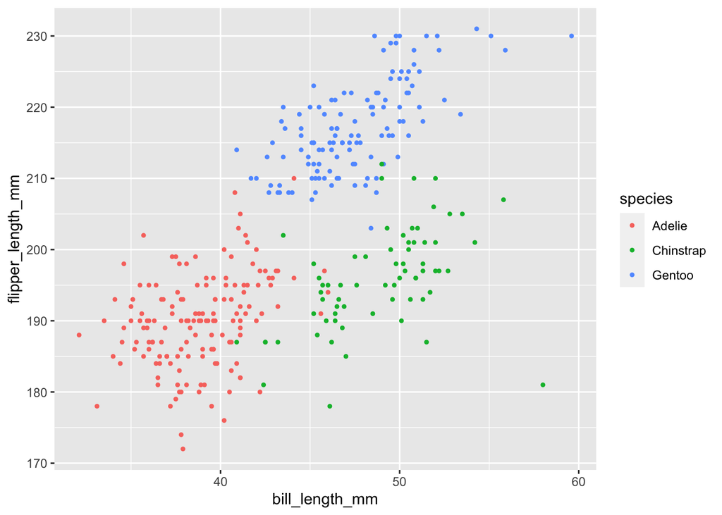

```r
scatterplot = ggplot(penguins,aes(x = bill_length_mm,y = flipper_length_mm,color = species)) + geom_point(shape = 20)
scatterplot
```

```r
ggsave("scatterplot_hw1.png", scatterplot)
```

## Problem 2

```r
  problem2_df =
  tibble(
  norm = rnorm(n = 10),
  logical_vector = norm > 0,
  character_vector = c("1","2","3","4","5","6","7","8","9","10"),
  factor_vector = factor(c("first","first","first","second","second","second","second","second","third","third"))
  )
```

```r
mean(pull(problem2_df, norm))
```

```
## [1] -0.03187801
```

```r
mean(pull(problem2_df, logical_vector))
```

```
## [1] 0.6
```

```r
mean(pull(problem2_df, character_vector))
```

```
## [1] NA
```

```r
mean(pull(problem2_df, factor_vector))
```

```
## [1] NA
```

According to the output of code above, we can learn that “norm” and “logical” variable can output the mean because their arguments are numeric or logical. “character_vector” and “factor_vector” doesn’t work with the mean and return NA since arguments are not numeric or logical

```r
logical_vector2 = as.numeric(pull(problem2_df, logical_vector))
character_vector2 = as.numeric(pull(problem2_df, character_vector))
factor_vector2 = as.numeric(pull(problem2_df, factor_vector))
```

```r
mean(logical_vector2)
```

```
## [1] 0.6
```

```r
mean(character_vector2)
```

```
## [1] 5.5
```

```r
mean(factor_vector2)
```

```
## [1] 1.9
```

According to the code above, we can learn that after converting logical, character and factor vectors into numeric type using as.numeric, the mean of character and factor variables can be worked out. Thus, the reason is that mean function can only work with numeric and logical data type. Character and factor type of data should be converted into numeric in order to get the mean output.